# REPRODUCIBLE RESEARCH: Peer Assessment 1

=================================================================================

## Loading and preprocessing the data

### 1. Load the data (i.e. read.csv())

```r
library(ggplot2)

GetData <- function(){

# Create a working directory
    if(!file.exists("./My WorkingDir")){dir.create("./My WorkingDir")}
    # dir.create("./My WorkingDir")
    fileUrl <- "https://d396qusza40orc.cloudfront.net/repdata%2Fdata%2Factivity.zip"

# Download the files  in the working directory
    download.file(fileUrl,destfile="./My WorkingDir/Dataset.zip")
    unzip(zipfile="./My WorkingDir/Dataset.zip",exdir=getwd())
    FilePath <- getwd()


# read "activity.csv" file
    MyData <- read.csv("activity.csv")

head(MyData, 5)
names(MyData)

}
GetData()
```

[output not shown]

### 2.Process/transform the data (if necessary) into a format suitable for your analysis

```r
library(dplyr)
knit2html("activity.csv")
```

```
##
##
## processing file: activity.csv
```

```
## output file: activity.txt
```

```r
MyData <- read.csv("activity.csv")
MyData$date <- as.Date(MyData$date, format = "%Y-%m-%d")
```

## What is mean total number of steps taken per day?

### 1. Calculate the total number of steps taken per day

```r
    TotalStepsDaily <- tapply(MyData$steps, MyData$date, FUN=sum, na.rm=TRUE)
```

### 2. Make a histogram of the total number of steps taken per day

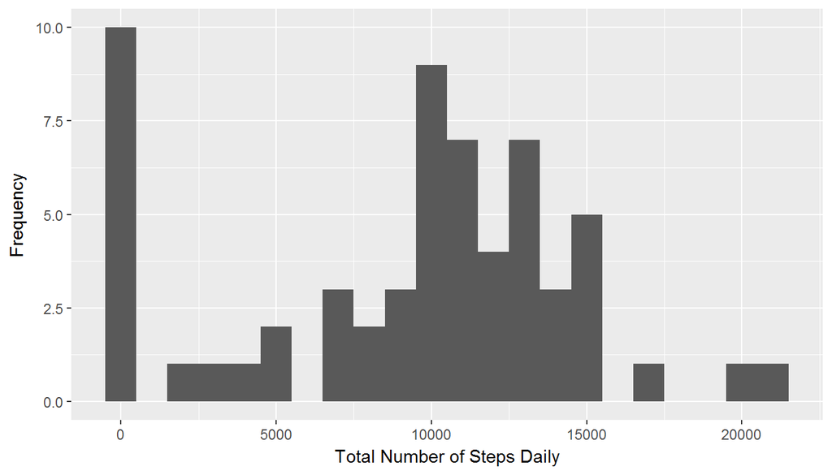

```r
    library(ggplot2)
    qplot(TotalStepsDaily, binwidth=1000, xlab="Total Number of Steps Daily", ylab="Frequency")
```

### 3. Calculate and report the mean and median total number of steps taken per day

```r
    StepsMeanDaily <- mean(TotalStepsDaily)
    StepsMedianDaily <- median(TotalStepsDaily)
```

The mean total number of steps daily is 9354.2295082 and the median of total number of steps daily is 10395

## What is the average daily activity pattern?

```r
    StepsByInterval <- aggregate(steps ~ interval, MyData, mean)
```

### 1. Make a time series plot (i.e. type = “l”) of the 5-minute interval (x-axis) and the average number of steps taken, averaged across all days (y-axis)

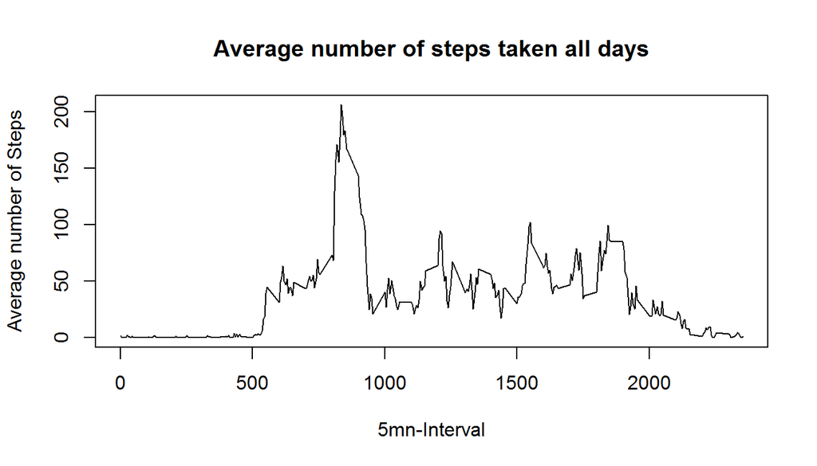

```r
    StepsByInterval <- aggregate(steps ~ interval, MyData, mean)
# Create a time series plot(i.e. type="l")
    plot(StepsByInterval$interval, StepsByInterval$steps, type='l', main="Average number of steps taken all days", xlab="5mn-Interval", ylab="Average number of Steps")
```

### 2. Which 5-minute interval, on average across all the days in the dataset, contains the maximum number of steps?

```r
# Find the 5-minute interval that contains the maximum number of steps
MyInterval <- which.max(StepsByInterval$steps)
time <- StepsByInterval[MyInterval,]$interval
MyTime <- sprintf("%04d", time)
MyTime <- format(strptime(MyTime, format="%H%M"), format="%H:%M")
```

### The Interval 08:35 has the maximum average value of steps

## Imputing missing values

### 1. Calculate and report the total number of missing values in the dataset (i.e. the total number of rows with NAs)

```r
# Total number of row's with NA's
sum(is.na(MyData))
```

```
## [1] 2304
```

### 2.Devise a strategy for filling in all of the missing values in the dataset. The strategy does not need to be sophisticated. For example, you could use the mean/median for that day, or the mean for that 5-minute interval, etc.

### 3. Create a new dataset that is equal to the original dataset but with the missing data filled in.

```r
    MyNewData <- MyData

for (i in 1:nrow(MyNewData)){
    if (is.na(MyNewData$steps[i])) {
        interval_value <- MyNewData$interval[i]
        steps_value <- StepsByInterval[StepsByInterval$interval == interval_value,]
        MyNewData$steps[i] <- steps_value$steps
    }
}

    MyFinalData <- aggregate(steps ~ date, MyNewData, sum)
    sum(is.na(MyNewData))
```

```
## [1] 0
```

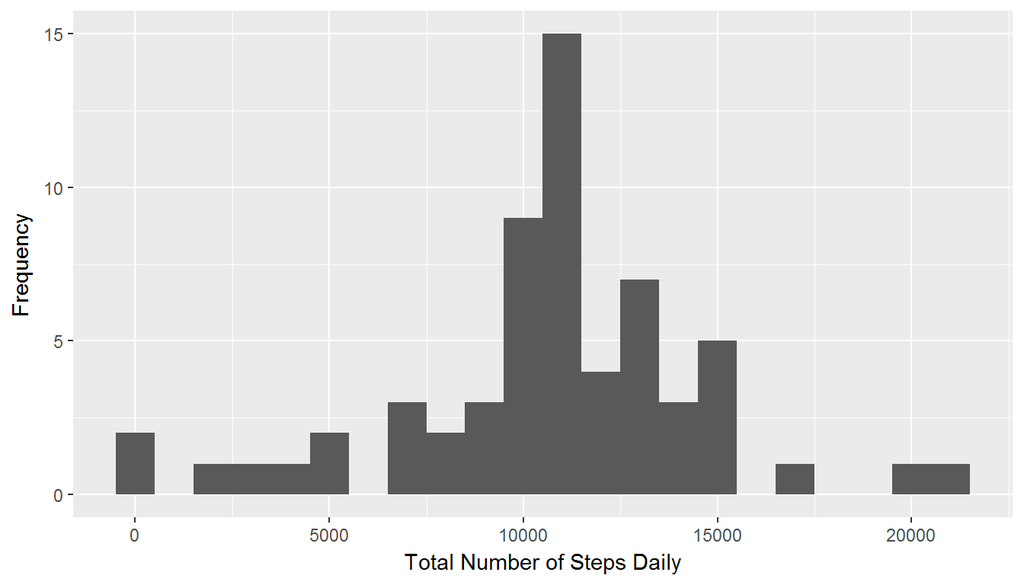

```r
    TotalStepsDaily2 <- tapply(MyNewData$steps, MyNewData$date, sum)
    qplot(TotalStepsDaily2, binwidth=1000, xlab="Total Number of Steps Daily", ylab="Frequency")
```

```r
StepsMeanDaily2 <- mean(TotalStepsDaily2)
StepsMedianDaily2 <- median(TotalStepsDaily2)
```

### Are there differences in activity patterns between weekdays and weekends?

#### 1. Create a new factor variable in the dataset with two levels - “weekday” and “weekend” indicating whether a given date is a weekday or weekend day.

```r
MyNewData['MyDay'] <- weekdays(MyNewData$date)
MyNewData$MyDay[MyNewData$MyDay %in% c('samedi', 'dimanche')] <- "weekend"
MyNewData$MyDay[MyNewData$MyDay != "weekend"] <- "weekday"
head(MyNewData)
```

```
##       steps       date interval   MyDay
## 1 1.7169811 2012-10-01        0 weekday
## 2 0.3396226 2012-10-01        5 weekday
## 3 0.1320755 2012-10-01       10 weekday
## 4 0.1509434 2012-10-01       15 weekday
## 5 0.0754717 2012-10-01       20 weekday
## 6 2.0943396 2012-10-01       25 weekday
```

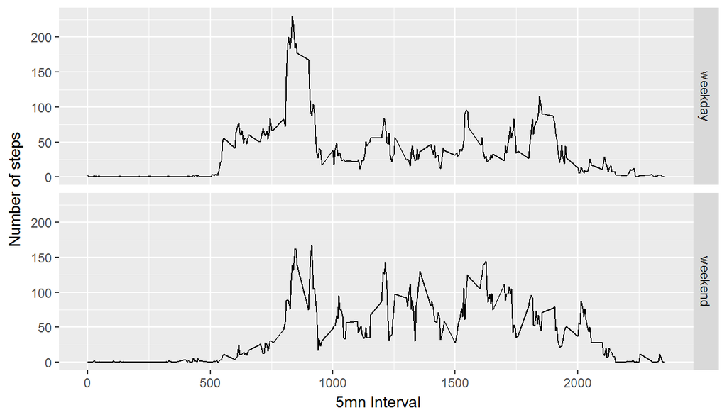

```r
MyNewData$MyDay <- as.factor(MyNewData$MyDay)
MyNewData_we <- subset(MyNewData, MyDay == "weekend")
MyNewData_wd <- subset(MyNewData, MyDay == "weekday")

DailyStepWe <- tapply(MyNewData_we$steps, MyNewData_we$interval, mean)
DailyStepWd <- tapply(MyNewData_wd$steps, MyNewData_wd$interval, mean)

par(mfrow=c(2,1))
MyFinalData <- aggregate(steps ~ interval + MyDay, MyNewData, mean)
ggplot(MyFinalData, aes(interval, steps)) + geom_line()+facet_grid(MyDay ~ .) +
xlab(" 5mn Interval") + ylab("Number of steps")
```